# A ggplot2 Tutorial for Beautiful Plotting in R

## The `{ggplot2}` Package

> `ggplot2` is a system for declaratively creating graphics, based on The Grammar of Graphics. You provide the data, tell `ggplot2` how to map variables to aesthetics, what graphical primitives to use, and it takes care of the details.

Consequently, a ggplot is built up from a few basic elements:

1. **Data**:  
   The raw data that you want to plot.
2. **Geometries** `geom_`:  
   The geometric shapes that will represent the data.
3. **Aesthetics** `aes()`:  
   Aesthetics of the geometric and statistical objects, such as position., color, size, shape, and transparency
4. **Scales** `scale_`:  
   Maps between the data and the aesthetic dimensions, such as data range to plot width or factor values to colors.
5. **Statistical transformations** `stat_`:  
   Statistical summaries of the data, such as quantiles, fitted curves, and sums.
6. **Coordinate system** `coord_`:  
   The transformation used for mapping data coordinates into the plane of the data rectangle.
7. **Facets** `facet_`:  
   The arrangement of the data into a grid of plots.
8. **Visual themes** `theme()`:  
   The overall visual defaults of a plot, such as background, grids, axes, default typeface, sizes and colors.

(The number of elements may vary depending on how you group them and whom you ask.)

**A Default ggplot**

First, to be able to use the functionality of `{ggplot2}` we have to load the package (which we can also load via the [tidyverse package collection](https://www.tidyverse.org/)):

```r
library(ggplot2)
#library(tidyverse)
```

The syntax of `{ggplot2}` is different from base R. In accordance with the basic elements, a default ggplot needs three things that you have to specify: the *data*, *aesthetics*, and a *geometry*. We always start to define a plotting object by calling `ggplot(data = df)` which just tells `{ggplot2}` that we are going to work with that data. In most cases, you might want to plot two variables—one on the x and one on the y axis. These are *positional aesthetics* and thus we add `aes(x = var1, y = var2)` to the `ggplot()` call (yes, the `aes()` stands for aesthetics). However, there are also cases where one has to specify one or even three or more variables.

💡 **We specify the data *outside*`aes()` and add the variables that ggplot maps the aesthetics to *inside*`aes()`.**

Here, we map the variable `date` to the x position and `temp` to the y position. Later, we will also map variables to all kind of other aesthetics such as colors, sizes, and shapes.

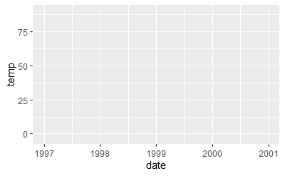

```r
(g <- ggplot(chic, aes(x = date, y = temp)))
```

Hm, only a panel is created when running this. Why? This is because `{ggplot2}` does not know *how* we want to plot that data—we still need to provide a geometry!

`ggplot2` allows you to store the current `ggobject` in a variable of your choice by assigning it to a variable, in our case called `g`. You can extend this `ggobject` later by adding other layers, either all at once or by assigning it to the same or another variable.

💡 **By using parentheses while assigning an object, the object will be printed immediately (instead of writing `g <- ggplot(...)` and then `g` we simply write `(g <- ggplot(...))`).**

There are many, many different geometries (called *geoms* because each function usually starts with `geom_`) one can add to a ggplot by default (see [here](https://ggplot2.tidyverse.org/reference/) for a full list) and even more provided by extension packages (see [here](https://exts.ggplot2.tidyverse.org/) for a collection of extension packages). Let’s tell `{ggplot2}` which style we want to use, for example by adding `geom_point()` to create a scatter plot:

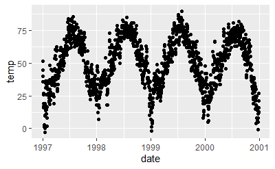

Nice! But this data could be also visualized as a line plot (not optimal, but people do things like this all the time). So we simply add `geom_line()` instead and voilá:

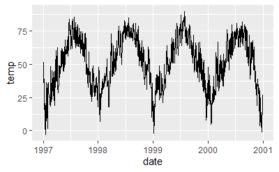

One can also combine several geometric layers—and this is where the magic and fun starts!

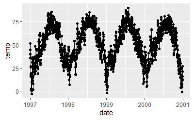

```r
g + geom_line() + geom_point()
```

That’s it for now about geometries. No worries, we are going to learn several plot types at [a later point](https://cedricscherer.netlify.app/2019/08/05/a-ggplot2-tutorial-for-beautiful-plotting-in-r/#charts).

##### Change Properties of Geometries

Within the `geom_*` command, you already can manipulate visual aesthetics such as the color, shape, and size of your points:

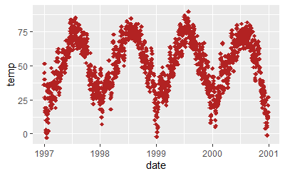

```r
g + geom_point(color = "firebrick", shape = "diamond", size = 2)
```

💡 **`{ggplot2}` understands both `color` and `colour` as well as the short version `col`.**

Each geom comes with its own properties (called *arguments*) and the same argument may result in a different change depending on the geom you are using.

```
Ignoring unknown parameters: typeIgnoring unknown parameters: line_type
```

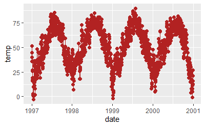

```r
g + geom_point(color = "firebrick", type = "diamond", size = 2) + geom_line( color = "firebrick", line_type = "dotted", size = .3)
```

**Replace the default `ggplot2` theme**

And to illustrate some more of ggplot’s versatility, let’s get rid of the grayish default `{ggplot2}` look by setting a different built-in theme, e.g. `theme_bw()`—by calling `theme_set()` all following plots will have the same black’n’white theme. The red points look way better now!

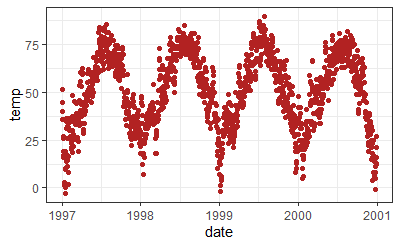

You can find more on how to use built-in themes and how to customize themes in the section [“Working with Themes”](https://cedricscherer.netlify.app/2019/08/05/a-ggplot2-tutorial-for-beautiful-plotting-in-r/#themes). From the next chapter on, we will also use the `theme()` function to customize particular elements of the theme.

💡 **`theme()` is an essential command to manually modify all kinds of theme elements (texts, rectangles, and lines).**

To see which details of a ggplot theme can be modified have a look [here](http://docs.ggplot2.org/current/theme.html)—and take some time, this is a looong list.

## Working with Axes

##### Increase Space between Axis and Axis Titles

💡 **A good way to remember the order of the margin sides is *t*-*r*-oub-*l*-*e*.**

Change Aesthetics of Axis Titles

The `face` argument can be used to make the font `bold` or `italic` or even `bold.italic`.

💁 *You could also use a combination of `axis.title` and `axis.title.y`, since `axis.title.x` inherits the values from `axis.title`. Expand to see example.*

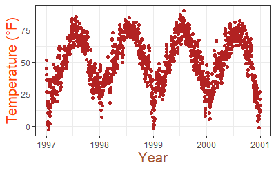

```r
ggplot(chic, aes(x = date, y = temp)) +
  geom_point(color = "firebrick") +
  labs(x = "Year", y = "Temperature (°F)") +
  theme(axis.title = element_text(color = "sienna", size = 15),
        axis.title.y = element_text(color = "orangered", size = 15))
```

**Change Aesthetics of Axis Text**

## Rotate Axis Text

##### Remove Axis Text & Ticks

I introduced three theme elements—text, lines, and rectangles—but actually there is one more: `element_blank()` which removes the element (and thus is not considered an official element).